# Vignette

### Importing and projecting .csv data

Now that we have defined the coordinate system of the shapefile, we can pull in the ranging data collected from the titi monkeys between July 2014 to June 2015. These data have been cleaned in advance and stored in a .csv file on GitHub.

```r
> f <- curl("https://raw.githubusercontent.com/Callicebus/vignette/master/GPScoordinates.csv")
> points <- read.csv(f)
> head(points)
```

```
##   Obs.Sample.ID     Date Month        Group     UTMX    UTMY
## 1       OS92719 4-Jul-14     7 Callicebus L 371667.0 9929338
## 2       OS92719 4-Jul-14     7 Callicebus L 371647.7 9929378
## 3       OS92719 4-Jul-14     7 Callicebus B 371664.1 9929523
## 4       OS92719 4-Jul-14     7 Callicebus B 371747.5 9929529
## 5       OS92719 4-Jul-14     7 Callicebus B 371711.8 9929542
## 6       OS92719 4-Jul-14     7 Callicebus B 371700.1 9929542
```

As you can see, the coordinates in this file are already in the UTM projection, but we will have to tell *R* that. This is also done through commands in the sp package. First, you’ll have to convert the .csv file to a dataframe for spatial points, and then set the right coordinate system.

```r
> spdf <- SpatialPointsDataFrame(coords = c(points[5], points[6]), data = points[4])  #Column 5 has the X-coordinates, column 6 has the Y-coordinates, and column 4 has important attribute data.
> str(spdf)
```

```
## Formal class 'SpatialPointsDataFrame' [package "sp"] with 5 slots
##   ..@ data       :'data.frame':  1719 obs. of  1 variable:
##   .. ..$ Group: Factor w/ 3 levels "Callicebus B",..: 3 3 1 1 1 1 1 1 2 2 ...
##   ..@ coords.nrs : num(0)
##   ..@ coords     : num [1:1719, 1:2] 371667 371648 371664 371747 371712 ...
##   .. ..- attr(*, "dimnames")=List of 2
##   .. .. ..$ : NULL
##   .. .. ..$ : chr [1:2] "UTMX" "UTMY"
##   ..@ bbox       : num [1:2, 1:2] 371376 9929241 372130 9929694
##   .. ..- attr(*, "dimnames")=List of 2
##   .. .. ..$ : chr [1:2] "UTMX" "UTMY"
##   .. .. ..$ : chr [1:2] "min" "max"
##   ..@ proj4string:Formal class 'CRS' [package "sp"] with 1 slot
##   .. .. ..@ projargs: chr NA
```

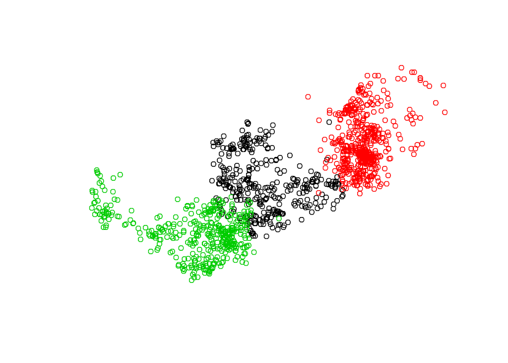

```r
> plot(spdf, pch = 1, col = spdf$Group)
```

```r
> utm <- SpatialPoints(spdf, proj4string = CRS("+proj=utm +zone=18 +south +datum=WGS84"))
>
> # If you would like to transform your data to Lat/Long rather then UTM, you
> # can use this code: latlong <- spTransform(utm, CRS('+proj=longlat
> # +datum=WGS84'))
>
> utm <- SpatialPointsDataFrame(utm, data = points[4])
> plot(tbs)
> plot(utm, pch = 20, col = utm$Group, add = T)  #Simply adding add = TRUE to your code will overlay the second plot on the first.
```

[output not shown]

If you want to zoom in or out on your plots, you can use a simple command from the {zoom} package. Here we have not put it in a code block, because you can only use this commend directly in your *R* console. Type the following: > inout.zoom()

Now you can zoom in by left-clicking on your plot. By right-clicking near the edge of your plot you can zoom out. Last, you can leave this function by hitting Escape.

## Part 2: Analyzing home range data

### Creating home range polygons and estimating home range size

Now that we have all points plotted, we can draw polygons around the points of each group, representing the home ranges of the monkeys during the one-year period. We’ll do this with the help of a package build especially for home range measurements. NOTE: the functions in this package work best if you use the UTM projections!

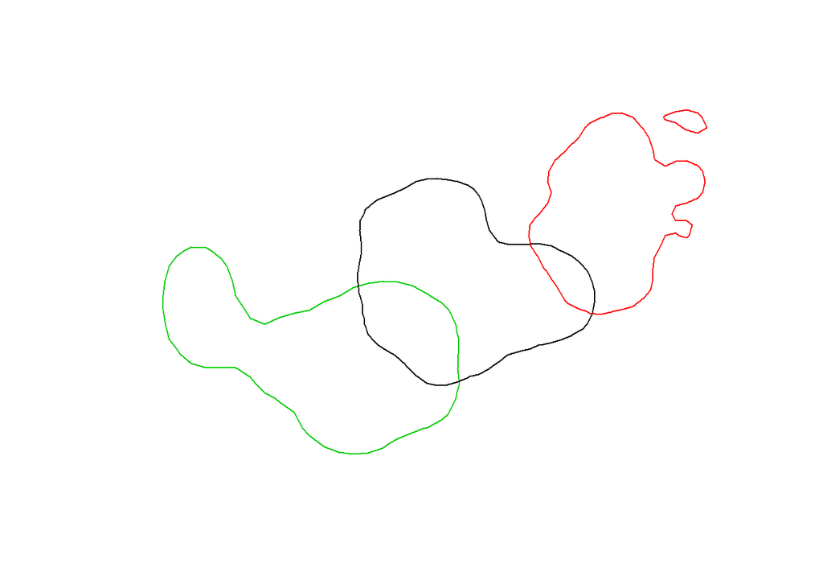

```r
> kernel <- kernelUD(utm[, 1], h = "href")
> TitiRange <- getverticeshr(kernel, 95)
> plot(TitiRange, border = TitiRange@data$id)
> plot(tbs, add = T)
```

We can now use these polygons to estimate home range size quite simply:

```r
> as.data.frame(TitiRange)
```

```
##                        id     area
## Callicebus B Callicebus B 6.195812
## Callicebus K Callicebus K 4.276863
## Callicebus L Callicebus L 6.643743
```

### How are home ranges used?

Let’s look only at the home range of Callicebus group L. Using our points, we can also find out which parts of their home range re used more often, and which parts are used less frequently. First, let’s subset the data so we only have the ranging points of Callicebus L.

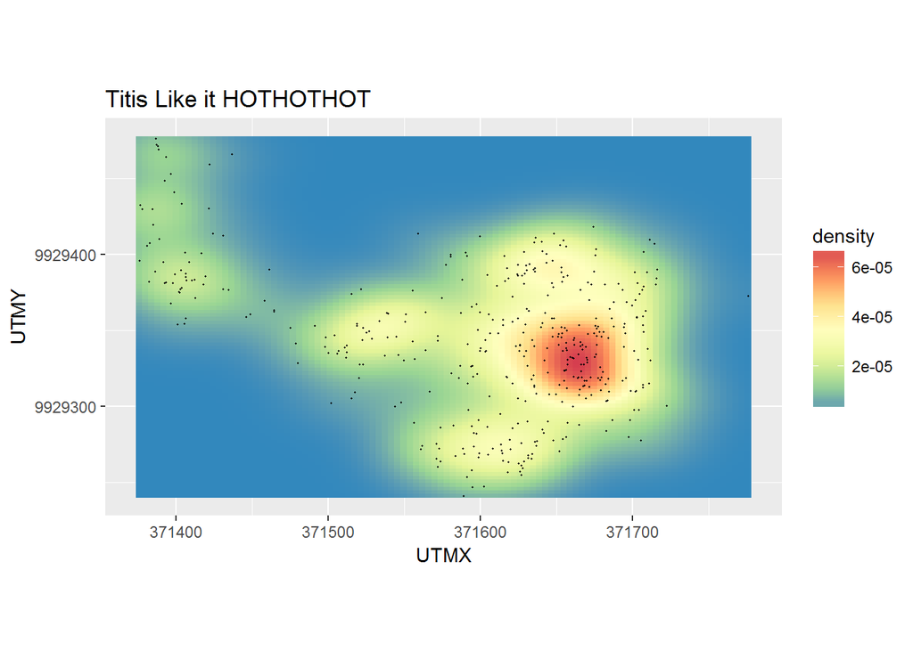

```r
> library(RColorBrewer)
> Lpoints <- points[points$Group == "Callicebus L", ]
> hothothot <- ggplot(Lpoints, aes(x = UTMX, y = UTMY)) + stat_density2d(aes(fill = ..density..),
+     geom = "tile", contour = FALSE) + geom_point(size = 0.25) + scale_fill_gradientn(colours = rev(brewer.pal(7,
+     "Spectral"))) + coord_fixed() + ggtitle("Titis Like it HOTHOTHOT")
> hothothot
```